# STAT 689 Homework 10

## Rohan Tiwari

### 1. We have talked about the spinal bone mineral density data, with the random intercept case. I stated that I think, or perhaps hope, that the id numbers should not have to be 1,2,3… I also think/hope that the idnumbers do not need to be ordered. It is generally the case that data sets are “cleaned” and there is a code book that converts the actual ids to 1,2,3,…,n. This helps de-identify data and helps preserve anonymity.

### 1a. Test this out in the spinal bone mineral density data, by defining a new variable, femSBMD$idnum2 = 2 * femSBMD$idnum

```r
library(HRW)
library(gamm4)
setwd("~/tamu/MS-STAT-2022/689-flexible-regression")
femSBMD = read.csv("femSBMD.csv")
femSBMD$idnum2 = 2*femSBMD$idnum
head(femSBMD)
```

```
##   X idnum spnbmd  age ethnicity black hispanic white idnum2
## 1 1     1  0.719 11.2     White     0        0     1      2
## 2 2     1  0.732 12.2     White     0        0     1      2
## 3 3     1  0.776 13.2     White     0        0     1      2
## 4 4     1  0.781 14.3     White     0        0     1      2
## 5 5     2  0.620 12.7     White     0        0     1      4
## 6 6     2  0.627 13.8     White     0        0     1      4
```

### 1b. Then rerun the gamm4::gamm4 given in class to see if you get the same results. I think/hope you will

```r
#original
origfit <- gamm4(spnbmd ~ s(age,k=10,bs="cr") + black + hispanic + white,
              random= ~(1|idnum),data = femSBMD)

#new
newfit <- gamm4(spnbmd ~ s(age,k=10,bs="cr") + black + hispanic + white,
              random= ~(1|idnum2),data = femSBMD)

summary(origfit$gam)
```

```
##
## Family: gaussian
## Link function: identity
##
## Formula:
## spnbmd ~ s(age, k = 10, bs = "cr") + black + hispanic + white
##
## Parametric coefficients:
##             Estimate Std. Error t value Pr(>|t|)
## (Intercept)  0.92535    0.01246  74.239  < 2e-16 ***
## black        0.08195    0.01722   4.758 2.24e-06 ***
## hispanic    -0.01511    0.01759  -0.859    0.391
## white        0.01508    0.01753   0.860    0.390
## ---
## Signif. codes:  0 '***' 0.001 '**' 0.01 '*' 0.05 '.' 0.1 ' ' 1
##
## Approximate significance of smooth terms:
##          edf Ref.df     F p-value
## s(age) 7.233  7.233 224.9  <2e-16 ***
## ---
## Signif. codes:  0 '***' 0.001 '**' 0.01 '*' 0.05 '.' 0.1 ' ' 1
##
## R-sq.(adj) =  0.519
## lmer.REML = -2386.2  Scale est. = 0.0013566  n = 1003
```

```r
summary(newfit$gam)
```

```
##
## Family: gaussian
## Link function: identity
##
## Formula:
## spnbmd ~ s(age, k = 10, bs = "cr") + black + hispanic + white
##
## Parametric coefficients:
##             Estimate Std. Error t value Pr(>|t|)
## (Intercept)  0.92535    0.01246  74.239  < 2e-16 ***
## black        0.08195    0.01722   4.758 2.24e-06 ***
## hispanic    -0.01511    0.01759  -0.859    0.391
## white        0.01508    0.01753   0.860    0.390
## ---
## Signif. codes:  0 '***' 0.001 '**' 0.01 '*' 0.05 '.' 0.1 ' ' 1
##
## Approximate significance of smooth terms:
##          edf Ref.df     F p-value
## s(age) 7.233  7.233 224.9  <2e-16 ***
## ---
## Signif. codes:  0 '***' 0.001 '**' 0.01 '*' 0.05 '.' 0.1 ' ' 1
##
## R-sq.(adj) =  0.519
## lmer.REML = -2386.2  Scale est. = 0.0013566  n = 1003
```

```r
anova(origfit$mer, newfit$mer)
```

```
## refitting model(s) with ML (instead of REML)
```

```
## Data: NULL
## Models:
## origfit$mer: NULL
## newfit$mer: NULL
##             npar     AIC     BIC logLik deviance Chisq Df Pr(>Chisq)
## origfit$mer    8 -2404.4 -2365.1 1210.2  -2420.4
## newfit$mer     8 -2404.4 -2365.1 1210.2  -2420.4     0  0
```

Both summary results match. So we can say that the particular value of idnum does not matter in gamm’s grouping.

### 2. Get the data set pigWeights.csv from Canvas. The variable weight is the response, and the variable num.weeks is the date of the repeated measures

```r
pigs = read.csv(file="pigWeights.csv")
head(pigs)
```

```
##   id.num num.weeks weight
## 1      1         1   24.0
## 2      1         2   32.0
## 3      1         3   39.0
## 4      1         4   42.5
## 5      1         5   48.0
## 6      1         6   54.5
```

### 2a. Display the lattice plot from library(lattice). Use the example from the spinal bone mineral density data to do this. I covered this in class, but in this case there is only 1 population and no ANCOVA.

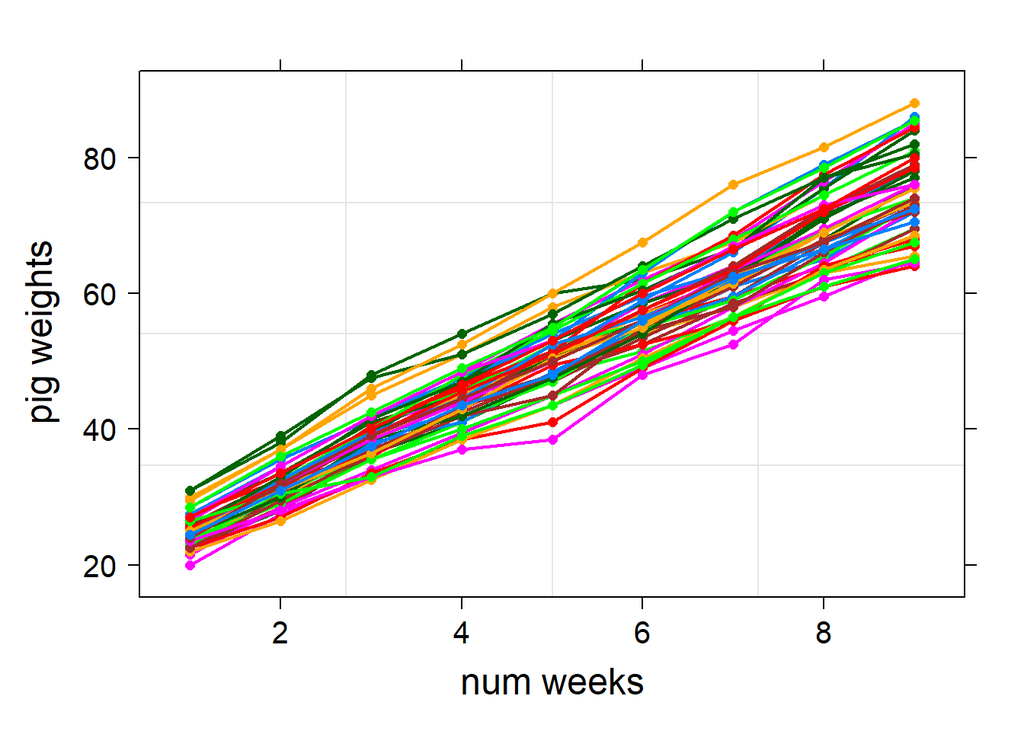

```r
library(lattice)
pigsvis = xyplot(weight ~ num.weeks,
                     group = id.num,as.table = TRUE,
                     data = pigs,
                     strip = strip.custom(par.strip.text
                                          = list(cex = 1.5)),
                     par.settings = list(layout.heights
                                         =list(strip=1.6)),
                     scales = list(cex = 1.25),
                     xlab = list("num weeks",cex = 1.5),
                     ylab = list(expression(paste(
                       "pig weights")),
                       cex = 1.5),
                     panel = function(x,y,subscripts,groups)
                     {
                       panel.grid()
                       panel.superpose(x,y,subscripts,groups,
                                       type = "b",pch = 16,lwd = 2)
                     })
plot(pigsvis)
```

### 2c. Fit the random intercept model with num_weeks modeled as a spline. Do a summary and show your results. Show the between-person variance of the intercept and the within-person variance of the random errors. You may use either mgcv::gamm or gamm4::gamm4.

```r
fitpigs <- gamm4(weight ~ s(I(num.weeks),k=8,bs="cr"),
             random= ~(1|id.num),data = pigs)

summary(fitpigs$gam)
```

```
##
## Family: gaussian
## Link function: identity
##
## Formula:
## weight ~ s(I(num.weeks), k = 8, bs = "cr")
##
## Parametric coefficients:
##             Estimate Std. Error t value Pr(>|t|)
## (Intercept)  50.4051     0.5706   88.33   <2e-16 ***
## ---
## Signif. codes:  0 '***' 0.001 '**' 0.01 '*' 0.05 '.' 0.1 ' ' 1
##
## Approximate significance of smooth terms:
##                   edf Ref.df    F p-value
## s(I(num.weeks)) 3.565  3.565 7251  <2e-16 ***
## ---
## Signif. codes:  0 '***' 0.001 '**' 0.01 '*' 0.05 '.' 0.1 ' ' 1
##
## R-sq.(adj) =   0.93
## lmer.REML = 2027.1  Scale est. = 4.2981    n = 432
```

```r
summary(fitpigs$mer)
```

```
## Linear mixed model fit by REML ['lmerMod']
##
## REML criterion at convergence: 2027.1
##
## Scaled residuals:
##     Min      1Q  Median      3Q     Max
## -3.8108 -0.5406  0.0071  0.4770  3.9433
##
## Random effects:
##  Groups   Name            Variance Std.Dev.
##  id.num   (Intercept)     15.1524  3.8926
##  Xr       s(I(num.weeks))  0.0139  0.1179
##  Residual                  4.2981  2.0732
## Number of obs: 432, groups:  id.num, 48; Xr, 6
##
## Fixed effects:
##                     Estimate Std. Error t value
## X(Intercept)         50.4051     0.5706   88.33
## Xs(I(num.weeks))Fx1 -46.0205     0.2864 -160.67
##
## Correlation of Fixed Effects:
##             X(Int)
## Xs(I(n.))F1 0.000
```

sigma_u^2 is 15.1524 sigma_e^2 is 4.2981

### 2d. Using anova() in gamm4::gamm4, to test whether a spline is needed as compared to a linear and a quadratic effect.

```r
fitL <- gamm4(weight ~ I(num.weeks),
              random= ~(1|id.num),data = pigs)
summary(fitL$gam)
```

```
##
## Family: gaussian
## Link function: identity
##
## Formula:
## weight ~ I(num.weeks)
##
## Parametric coefficients:
##              Estimate Std. Error t value Pr(>|t|)
## (Intercept)  19.35561    0.60314   32.09   <2e-16 ***
## I(num.weeks)  6.20990    0.03906  158.97   <2e-16 ***
## ---
## Signif. codes:  0 '***' 0.001 '**' 0.01 '*' 0.05 '.' 0.1 ' ' 1
##
##
## R-sq.(adj) =   0.93
## lmer.REML = 2033.8  Scale est. = 4.3947    n = 432
```

```r
fitQ <- gamm4(weight ~ I(num.weeks) + I(num.weeks^2),
              random= ~(1|id.num),data = pigs)
summary(fitQ$gam)
```

```
##
## Family: gaussian
## Link function: identity
##
## Formula:
## weight ~ I(num.weeks) + I(num.weeks^2)
##
## Parametric coefficients:
##                Estimate Std. Error t value Pr(>|t|)
## (Intercept)    19.08259    0.68101  28.021   <2e-16 ***
## I(num.weeks)    6.35882    0.17684  35.958   <2e-16 ***
## I(num.weeks^2) -0.01489    0.01725  -0.863    0.388
## ---
## Signif. codes:  0 '***' 0.001 '**' 0.01 '*' 0.05 '.' 0.1 ' ' 1
##
##
## R-sq.(adj) =   0.93
## lmer.REML = 2039.3  Scale est. = 4.3976    n = 432
```

```r
#compare fits
anova(fitpigs$mer,fitL$mer)
```

```
## refitting model(s) with ML (instead of REML)
```

```
## Data: NULL
## Models:
## fitL$mer: NULL
## fitpigs$mer: NULL
##             npar    AIC    BIC  logLik deviance  Chisq Df Pr(>Chisq)
## fitL$mer       4 2037.8 2054.1 -1014.9   2029.8
## fitpigs$mer    5 2037.1 2057.4 -1013.5   2027.1 2.7577  1    0.09679 .
## ---
## Signif. codes:  0 '***' 0.001 '**' 0.01 '*' 0.05 '.' 0.1 ' ' 1
```

```r
anova(fitpigs$mer,fitQ$mer)
```

```
## refitting model(s) with ML (instead of REML)
```

```
## Data: NULL
## Models:
## fitpigs$mer: NULL
## fitQ$mer: NULL
##             npar    AIC    BIC  logLik deviance Chisq Df Pr(>Chisq)
## fitpigs$mer    5 2037.1 2057.4 -1013.5   2027.1
## fitQ$mer       5 2039.1 2059.4 -1014.5   2029.1     0  0
```

Linear versus spline: The p-value is 0.09679 which indicates that spline model is not significant. Quadratic versus Spline: Does not produce a p-value.

### 2e. Compare the quadratic and linear fits as well

```r
anova(fitQ$mer,fitL$mer)
```

```
## refitting model(s) with ML (instead of REML)
```

```
## Data: NULL
## Models:
## fitL$mer: NULL
## fitQ$mer: NULL
##          npar    AIC    BIC  logLik deviance  Chisq Df Pr(>Chisq)
## fitL$mer    4 2037.8 2054.1 -1014.9   2029.8
## fitQ$mer    5 2039.1 2059.4 -1014.5   2029.1 0.7488  1     0.3869
```

The p-value is 0.3869 which means quadratic model is not significant. So overall, we can see that linear model might be the best fit here.

### 2f. As in the spinal bone mineral density data, plot the fixed effects function against num.weeks, and include a pointwise 95% confidence interval for it.

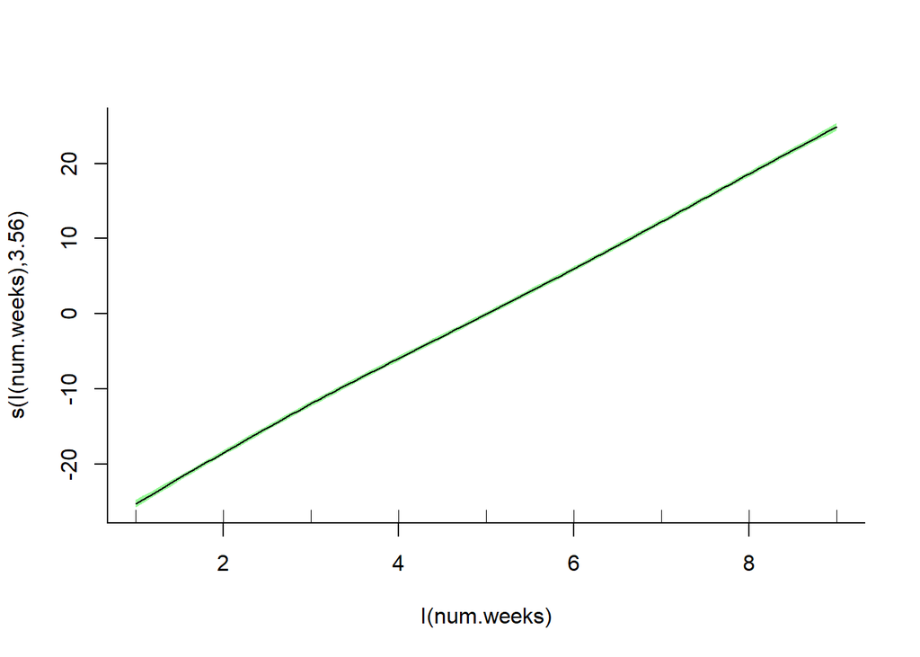

```r
plot(fitpigs$gam,shade = TRUE,shade.col = "palegreen",bty = "l")
```

### 2g. Since you have already computed var(U) and var( ε ), what is the estimated withinperson correlation for this model?

```r
#sigma_u^2 is 15.1524
#sigma_e^2 is 4.2981
ratio = 4.2981/15.1524
corr = (1 + ratio) ^ -1
print("Within person correlation is: ")
```

```
## [1] "Within person correlation is: "
```

```r
corr
```

```
## [1] 0.7790237
```